# **RF airline**

Group 07

# Route network

Based on forecasts, the airline’s load-factor policy, and marketing analysis, our airline (IATA code: RF) has proposed providing three daily round-trip flights from YVR to LAX, MCO, SLC, YLW, YXC, YXE and ZIH.

Airport information

| Airp. Code | City | Country |
| --- | --- | --- |
| YVR | Vancouver | Canada |
| LAX | Los Angeles | USA |
| MCO | Orlando | USA |
| SLC | Salt Lake City | USA |
| YLW | Kelowna | Canada |
| YXC | Cranbrook | Canada |
| YXE | Saskatoon | Canada |
| ZIH | Ixtapa/zihuatanejo | Mexico |

With a route network like:

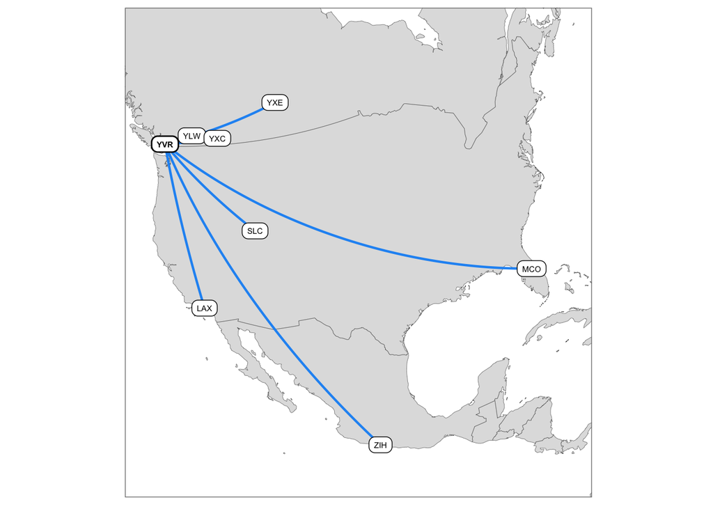

We have two types of fleet, namely Airbus A320 and Airbus A340-500. The seating capacities for these two fleet types are 197 and 237 seats respectively. Furthermore, we have the following information for this airline:

- Cost per available seat kilometer (CASK) for A320 and A340-500 are 0.038€ (3.8 cents) and 0.041€ (4.1 cents) respectively.
- Revenue per available seat kilometer (RASK) for A320 and A340-500 are 0.128€ (12.8 cents) and 0.128€ (12.8 cents) respectively.

Assume that we have 6 and 9 aircrafts in our A320 and A340-500 fleets, respectively. Due to the small size of our airline we are unable to recapture passengers that were spilled. Also assume turnaround times of 40 and 55 minutes for these two fleet types respectively. Furthermore, sit-connection times for crew members will range from 20 to 170 minutes for A320 and 15 to 180 minutes for A340-500.

# Flight schedule

We have also developed a first draft of our schedule for the next quarter. The complete flight schedule route, incorporating the 42 flights per day, is presented in the following table. All the arrival and departure times are local times.

Flight schedule

| Flight no. | Origin | Departure time | Destination | Arrival time | Flight time |
| --- | --- | --- | --- | --- | --- |
| RF0001 | MCO | 06:15 | YVR | 11:49 | 05:34 |
| RF0002 | YXC | 07:05 | YVR | 08:35 | 01:30 |
| RF0003 | YVR | 07:20 | SLC | 09:52 | 02:32 |
| RF0004 | ZIH | 07:35 | YVR | 13:00 | 05:25 |
| RF0005 | YVR | 08:10 | ZIH | 13:35 | 05:25 |
| RF0006 | ZIH | 08:35 | YVR | 14:00 | 05:25 |
| RF0007 | YXC | 08:40 | YVR | 10:10 | 01:30 |
| RF0008 | YVR | 09:20 | MCO | 14:54 | 05:34 |
| RF0009 | SLC | 09:25 | YVR | 11:57 | 02:32 |
| RF0010 | YXC | 09:40 | YVR | 11:10 | 01:30 |
| RF0011 | YVR | 10:10 | YXE | 12:06 | 01:56 |
| RF0012 | YVR | 11:00 | SLC | 13:32 | 02:32 |
| RF0013 | YVR | 11:10 | LAX | 14:05 | 02:55 |
| RF0014 | YLW | 11:25 | YVR | 12:28 | 01:03 |
| RF0015 | YVR | 12:15 | LAX | 15:10 | 02:55 |
| RF0016 | YVR | 12:20 | YLW | 13:23 | 01:03 |
| RF0017 | LAX | 12:45 | YVR | 15:40 | 02:55 |
| RF0018 | YXE | 12:50 | YVR | 14:46 | 01:56 |
| RF0019 | YVR | 13:10 | YXE | 15:06 | 01:56 |
| RF0020 | SLC | 14:00 | YVR | 16:32 | 02:32 |
| RF0021 | MCO | 14:20 | YVR | 19:54 | 05:34 |
| RF0022 | YVR | 14:35 | ZIH | 20:00 | 05:25 |
| RF0023 | YLW | 15:00 | YVR | 16:03 | 01:03 |
| RF0024 | YVR | 15:20 | MCO | 20:54 | 05:34 |
| RF0025 | SLC | 15:45 | YVR | 18:17 | 02:32 |
| RF0026 | YVR | 15:50 | YXC | 17:20 | 01:30 |
| RF0027 | YVR | 16:45 | YXE | 18:41 | 01:56 |
| RF0028 | ZIH | 16:50 | YVR | 22:15 | 05:25 |
| RF0029 | MCO | 16:55 | YVR | 22:29 | 05:34 |
| RF0030 | YXE | 17:25 | YVR | 19:21 | 01:56 |
| RF0031 | YVR | 17:30 | MCO | 23:04 | 05:34 |
| RF0032 | YVR | 17:50 | YLW | 18:53 | 01:03 |
| RF0033 | LAX | 18:00 | YVR | 20:55 | 02:55 |
| RF0034 | YVR | 18:00 | ZIH | 23:25 | 05:25 |
| RF0035 | YXE | 18:30 | YVR | 20:26 | 01:56 |
| RF0036 | LAX | 19:00 | YVR | 21:55 | 02:55 |
| RF0037 | YLW | 19:10 | YVR | 20:13 | 01:03 |
| RF0038 | YVR | 19:10 | LAX | 22:05 | 02:55 |
| RF0039 | YVR | 20:10 | YXC | 21:40 | 01:30 |
| RF0040 | YVR | 20:45 | SLC | 23:17 | 02:32 |
| RF0041 | YVR | 21:15 | YLW | 22:18 | 01:03 |
| RF0042 | YVR | 21:45 | YXC | 23:15 | 01:30 |

# Flight information

The following table presents the demand distribution for each flight as well as distances between cities. It is assumed that demand for each flight is normally distributed with the given means and standard deviations.

Flight information

| Flight no. | Origin | Destination | Distance (km) | Demand (mean) | Demand (sd) |
| --- | --- | --- | --- | --- | --- |
| RF0001 | MCO | YVR | 4221 | 171 | 28 |
| RF0002 | YXC | YVR | 538 | 187 | 32 |
| RF0003 | YVR | SLC | 1281 | 218 | 31 |
| RF0004 | ZIH | YVR | 4015 | 185 | 27 |
| RF0005 | YVR | ZIH | 4015 | 187 | 29 |
| RF0006 | ZIH | YVR | 4015 | 215 | 27 |
| RF0007 | YXC | YVR | 538 | 221 | 30 |
| RF0008 | YVR | MCO | 4221 | 215 | 37 |
| RF0009 | SLC | YVR | 1281 | 206 | 25 |
| RF0010 | YXC | YVR | 538 | 223 | 22 |
| RF0011 | YVR | YXE | 1205 | 186 | 28 |
| RF0012 | YVR | SLC | 1281 | 235 | 33 |
| RF0013 | YVR | LAX | 1740 | 232 | 25 |
| RF0014 | YLW | YVR | 286 | 226 | 25 |
| RF0015 | YVR | LAX | 1740 | 222 | 27 |
| RF0016 | YVR | YLW | 286 | 193 | 30 |
| RF0017 | LAX | YVR | 1740 | 216 | 36 |
| RF0018 | YXE | YVR | 1205 | 219 | 30 |
| RF0019 | YVR | YXE | 1205 | 208 | 27 |
| RF0020 | SLC | YVR | 1281 | 192 | 21 |
| RF0021 | MCO | YVR | 4221 | 201 | 27 |
| RF0022 | YVR | ZIH | 4015 | 174 | 35 |
| RF0023 | YLW | YVR | 286 | 192 | 29 |
| RF0024 | YVR | MCO | 4221 | 179 | 27 |
| RF0025 | SLC | YVR | 1281 | 178 | 26 |
| RF0026 | YVR | YXC | 538 | 230 | 32 |
| RF0027 | YVR | YXE | 1205 | 223 | 31 |
| RF0028 | ZIH | YVR | 4015 | 241 | 39 |
| RF0029 | MCO | YVR | 4221 | 233 | 20 |
| RF0030 | YXE | YVR | 1205 | 228 | 32 |
| RF0031 | YVR | MCO | 4221 | 231 | 32 |
| RF0032 | YVR | YLW | 286 | 231 | 32 |
| RF0033 | LAX | YVR | 1740 | 206 | 31 |
| RF0034 | YVR | ZIH | 4015 | 203 | 30 |
| RF0035 | YXE | YVR | 1205 | 226 | 25 |
| RF0036 | LAX | YVR | 1740 | 202 | 38 |
| RF0037 | YLW | YVR | 286 | 215 | 30 |
| RF0038 | YVR | LAX | 1740 | 226 | 22 |
| RF0039 | YVR | YXC | 538 | 230 | 30 |
| RF0040 | YVR | SLC | 1281 | 222 | 23 |
| RF0041 | YVR | YLW | 286 | 220 | 34 |
| RF0042 | YVR | YXC | 538 | 187 | 28 |